# DATA SCIENCE LATAM

UN ESPACIO PARA NUNCA PARAR DE APRENDER!!

Francisco Zambrano Cruz. Abril 2020.

[figure not shown]

# Muestreo y Entrenamiento de un Modelo en R

- Introduccion
- Bias
- Muesteo aleatorio simple
- Muestreo aleatorio estratificado
- Muestreo de conglomerados
- Muestreo aleatorio simple en R
- Muestreo estratificado en R
- Training y Testing
- Conjuntos de entrenamiento y prueba: modelado de clasificación
- Cross-Validation (Validación cruzada)
- K-fold Cross-Validation para elegir el grado del polinomio

## Introducción

El **muestreo** y el **aprendizaje automático** van de la mano. En el aprendizaje automático, generalmente comenzamos con un gran conjunto de datos que queremos usar para predecir algo. Por lo general, dividimos estos datos en un conjunto de entrenamiento y construimos un modelo alrededor de eso, y luego desatamos un modelo completamente entrenado en algún tipo de conjunto de prueba para ver cuál es el resultado final. En algunos casos, puede ser muy difícil ejecutar un modelo de aprendizaje automático en un conjunto de datos completo, mientras que podríamos lograr una precisión tan buena al ejecutar una pequeña muestra del mismo y realizar pruebas cuando sea apropiado. Esto podría deberse al tamaño de los datos, por ejemplo.

Primero definamos algunos **términos estadísticos**. Una **población** es la colección completa (o universo) de cosas bajo consideración.Una muestra es una porción de la población que seleccionamos para el análisis. Entonces, por ejemplo, podríamos comenzar con un conjunto de datos completo, dividir un fragmento en una muestra y hacer nuestro entrenamiento allí. Otra forma de verlo es que algunos datos que nos dan para comenzar podrían ser solo una muestra de un conjunto de datos mucho más amplio.

Los datos de las **encuestas** son un ejemplo de **muestreo**, y generalmente se recopilan haciendo preguntas a las personas sobre datos demográficos específicos.

En el mundo de la ciencia estadística, tenemos valores asociados con la población total y los asociados con muestras más pequeñas de esa población, como se muestra en la Figura:

[figure not shown]

Cuando hablamos de valores relacionados con los términos **media , varianza y desviación estándar** en relación con la población total, estos se denominan **parámetros**. Cuando hablamos de esos mismos valores, pero específicos de un determinado **subconjunto de datos**, los llamamos **estadísticos**.

## Bias

**El sesgo (Bias) de muestreo** es lo que sucede cuando muestreas datos de tal manera que las distribuciones de datos en las muestras no coinciden con las distribuciones de la población de la que estás extrayendo. Su muestra estaría sesgada en gran medida de una forma u otra.

**La variación de muestreo** es el grado en que una estadístico de muestra difiere de la población. Ambos pueden controlarse eligiendo la forma correcta de muestrear nuestros datos.

**El bias y la varianza** de muestreo se pueden representar de cuatro maneras. La Figura siguiente muestra cuatro objetivos de tiro al blanco, siendo el centro de cada uno la media de la población. Los puntos azules podrían representar diferentes encuestas que ejecutamos (diferentes muestras):

[figure not shown]

Al tomar muestras de datos, debe tener cuidado con los cuatro niveles diferentes de sesgo y varianza que podría tener

1. **Bajo sesgo(bias), baja varianza**: El mejor de los casos. Las muestras son bastante representativas de la población.
1. **Alto sesgo(bias), baja varianza**: Todas las muestras son bastante consistentes, pero no reflejan realmente a la población.
1. **Bajo sesgo(bias), alta varianza**: Las muestras varían enormemente en su consistencia, pero algunas pueden ser representativas de la población.
1. **Alto sesgo(bias), alta varianza**:Las muestras son un poco más consistentes, pero no es probable que sean representativas de la población.

## Muesteo aleatorio simple

Una **muestra aleatoria simple** es una forma de controlar el **sesgo** al extraer muestras de una población. Esto es cuando selecciona valores de sus datos al azar, de modo que cada fila tiene la misma posibilidad de ser seleccionada, como se muestra en la Figura siguiente. Este suele ser el mejor equilibrio entre la simplicidad y la representación de la población en general. La aplicación de una muestra aleatoria simple a los mismos datos dos veces tendrá la posibilidad de seleccionar los mismos datos, si es realmente aleatorio.

[figure not shown]

## Muestreo aleatorio estratificado

Otra forma común de muestreo se llama **muestreo aleatorio estratificado (o sobremuestreo)**. Esto es cuando separa los datos en grupos mutuamente excluyentes, llamados estratos , y luego hace una muestra aleatoria simple en cada estrato, como se muestra en la Figura siguiente. Esto sería como sondear al azar en todo el estado de cada país. Esto tiene dos ventajas sobre una muestra aleatoria simple:

- Asegura la representación en cada estrato.
- Puede ser más preciso que una muestra aleatoria simple si hay más variación en un estrato que en otros.

[figure not shown]

Una muestra aleatoria estratificada es cuando selecciona aleatoriamente de varios estratos en sus datos (un estrato podría ser una agrupación o corte en los datos que separan una parte de la otra; esto podría deberse también a la clasificación o factores variables en los datos)

## Muestreo de conglomerados

Si, por ejemplo, las muestras se distribuyen geográficamente o espacialmente, puede realizar una **muestra de conglomerados**; por ejemplo, cuando tiene datos estratificados por país o ciudad. Esto es similar hacer una muestra aleatoria estratificada, pero seleccionando todos los estratos al azar en lugar de hacer una muestra aleatoria simple dentro de los estratos, como se ilustra en la Figura siguiente:

[figure not shown]

Todo esto hasta ahora habla de implementación, pero no dice nada acerca de qué tan grande de una muestra debería estar tomando. La respuesta aquí, invariablemente, es "depende". Tomar el 100% de la población como muestra no siempre es el mejor enfoque. Sin embargo, debe lograr un equilibrio tal que su muestra tenga suficientes puntos de datos para ser estadísticamente significativos y bien representativos de las estadísticas de población que está viendo.

## Muestreo aleatorio simple en R

Es bastante fácil realizar todas las técnicas de muestreo mencionadas anteriormente en R. Si comenzamos con algunos datos de ejemplo, por ejemplo, el data set iris, podemos probar algunas de estas técnicas de muestreo utilizando el código R:

```r
iris.df <- data.frame(iris)

# primero se genera los indices segun la cantidad de filas del data set.
# Luego se extrae una muestra (75%) de los indices generados sin reemplazo
sample.index <- sample(1:nrow(iris.df), nrow(iris) * 0.75, replace = FALSE)

head(iris[sample.index, ])
```

|  | Sepal.Length | Sepal.Width | Petal.Length | Petal.Width | Species |
| --- | --- | --- | --- | --- | --- |
| 48 | 4.6 | 3.2 | 1.4 | 0.2 | setosa |
| 6 | 5.4 | 3.9 | 1.7 | 0.4 | setosa |
| 106 | 7.6 | 3.0 | 6.6 | 2.1 | virginica |
| 18 | 5.1 | 3.5 | 1.4 | 0.3 | setosa |
| 134 | 6.3 | 2.8 | 5.1 | 1.5 | virginica |
| 102 | 5.8 | 2.7 | 5.1 | 1.9 | virginica |

## Muestreo estratificado en R

Veamos cómo hacer un **muestreo estratificado en R**. A diferencia de la muestra aleatoria simple, el muestreo estratificado se puede realizar sobre diferentes características en el conjunto de datos. Expandamos esto al observar las distribuciones de datos en el dataset iris:

```r
summary(iris[sample.index, ])
```

```
  Sepal.Length    Sepal.Width     Petal.Length   Petal.Width          Species
 Min.   :4.300   Min.   :2.000   Min.   :1.00   Min.   :0.100   setosa    :40
 1st Qu.:5.100   1st Qu.:2.800   1st Qu.:1.50   1st Qu.:0.300   versicolor:36
 Median :5.700   Median :3.000   Median :4.20   Median :1.300   virginica :36
 Mean   :5.814   Mean   :3.071   Mean   :3.68   Mean   :1.168
 3rd Qu.:6.400   3rd Qu.:3.300   3rd Qu.:5.10   3rd Qu.:1.800
 Max.   :7.900   Max.   :4.400   Max.   :6.70   Max.   :2.500
```

Este ejemplo toma una muestra del 75% de los datos originales, y puede ver que las distribuciones están muy cerca de los valores de la población principal. Ahora intentemos el muestreo estratificado. Para esto, necesita el paquete **fifer** y la función **stratified()**

```r
#install_url("http://cran.r-project.org/src/contrib/Archive/fifer/fifer_1.1.tar.gz")
```

```r
#instalar esta libreria para usar la función "stratified"
library(devtools)
source_gist("https://gist.github.com/mrdwab/6424112")
```

```r
summary(stratified(iris, "Sepal.Length", 0.7))
```

```
  Sepal.Length    Sepal.Width     Petal.Length    Petal.Width
 Min.   :4.300   Min.   :2.000   Min.   :1.000   Min.   :0.100
 1st Qu.:5.100   1st Qu.:2.800   1st Qu.:1.600   1st Qu.:0.375
 Median :5.800   Median :3.000   Median :4.450   Median :1.350
 Mean   :5.867   Mean   :3.034   Mean   :3.871   Mean   :1.246
 3rd Qu.:6.425   3rd Qu.:3.300   3rd Qu.:5.100   3rd Qu.:1.800
 Max.   :7.900   Max.   :4.400   Max.   :6.900   Max.   :2.500
       Species
 setosa    :33
 versicolor:36
 virginica :39
```

La muestra estratificada tiene casi los mismos valores. Realizamos un muestreo estratificado de los datos iris utilizando la stratified()función, centrándonos específicamente en los estratos de **Sepal.Length**.

Sin embargo, con el **muestreo estratificado**, puede especificar qué estratos particulares desea muestrear. Si está muestreando muchos estratos, generalmente desea comenzar con las características que varían menos y luego avanzar hacia arriba. Las características con la varianza más baja del dataset iris cson Sepal.Widthy Petal.Width, así que comencemos con esas:

```r
summary(stratified(iris, c("Sepal.Width", "Petal.Width"), 0.7))
```

```
  Sepal.Length    Sepal.Width     Petal.Length    Petal.Width         Species
 Min.   :4.300   Min.   :2.000   Min.   :1.100   Min.   :0.10   setosa    :37
 1st Qu.:5.100   1st Qu.:2.800   1st Qu.:1.600   1st Qu.:0.30   versicolor:38
 Median :5.800   Median :3.000   Median :4.350   Median :1.30   virginica :41
 Mean   :5.863   Mean   :3.055   Mean   :3.817   Mean   :1.22
 3rd Qu.:6.400   3rd Qu.:3.300   3rd Qu.:5.100   3rd Qu.:1.80
 Max.   :7.900   Max.   :4.400   Max.   :6.900   Max.   :2.50
```

Puede ver en el resultado que el muestreo estratificado con múltiples grupos todavía tiene una buena representación de los datos de población (es decir, el data set iris completo ) con los que comenzó. Los medias y las variaciones parecen bastante apropiados para una muestra.

## Training y Testing

Al crear un modelo predictivo, debe pasar por fases de validación para asegurarse de que puede confiar en sus resultados. Si construye un modelo, necesita una forma verificable de asegurarse de que está obteniendo algo que parece la respuesta correcta primero antes de volverse loco y comenzar a ponerlo en producción. Necesita una forma de ver cuáles serán los errores generados por el modelo para poder ajustarlo mejor también.

Por ejemplo, si desea predecir el valor de algún precio de acciones mañana para el cual es imposible obtener los datos, podría construir un modelo que esté capacitado en datos de hace unos días y probarlo en los datos que tiene de ayer. Debido a que ya tiene las respuestas para los precios de las acciones de ayer, ver los resultados del modelo y comparar los números puede proporcionar comentarios valiosos para ver si el modelo está funcionando.

Es posible que haya visto modelos de aprendizaje automático utilizando una metodología de entrenamiento y prueba. Esto es cuando toma algunos datos, muestra la mayoría de ellos en un conjunto de entrenamiento y conserva lo que queda para un conjunto de prueba. Por lo general, hacemos una división de 70/30 de los datos en los subconjuntos de entrenamiento / prueba, pero no es raro ver divisiones 80/20 también. Lo que logra haciendo esto es simular efectivamente el modelo de trabajo ejecutándolo primero en los datos que ya tiene, antes de arrojar datos completamente nuevos. Hay dos suposiciones principales con las que trabajamos cuando hacemos estas divisiones de entrenamiento / prueba:

- Los datos son una representación justa de los procesos reales que desea modelar (es decir, el subconjunto refleja con precisión la población).
- Los procesos que desea modelar son relativamente estables en el tiempo y que un modelo construido con los datos del mes pasado debe reflejar con precisión los datos del próximo mes.

Si sus suposiciones son correctas, un modelo construido sobre los datos de hoy (o de ayer), debería funcionar en cualquier información futura que pase a través de ellos. Sin embargo, debe tener cuidado con la forma en que divide sus datos de entrenamiento y prueba. A continuación detalla diferentes formas para que usted muestree y subconjunte sus datos iniciales de manera que conserve la distribución general de las características de los datos.

**Roles del data set de entrenamiento y pruebas**

El papel del conjunto de datos de entrenamiento es proporcionar una plataforma sobre la cual el modelo que elija se base en su forma matemática de determinar los coeficientes. La función del conjunto de datos de prueba es ver qué tan bien se compara ese modelo con los datos reales.

**¿Por qué hacer un conjunto de prueba?**

Hay dos formas de pensar en el valor de hacer un conjunto de prueba de sus datos para fines de modelado. La primera es solo una forma sólida de validar esos datos. Si tenía un modelo que funcionó realmente bien para todos los datos en los que se entrenó, pero se bloqueó y se quemó cuando se le presentaron datos nuevos, el modelo pierde todo su poder predictivo y no es mejor que un informe estático. En el peor de los casos, ¡puede ser muy engañoso cómo debe pensar acerca de los valores en el futuro! Por lo tanto, poder ver que el modelo funciona mal antes de tiempo es valioso en sí mismo. Esa información puede informarle que solo necesita ajustar el parámetro X en una pequeña cantidad para que se ajuste, por ejemplo.

La otra necesidad valiosa de un conjunto de pruebas es que algunos algoritmos de aprendizaje automático realmente dependen de uno para existir en primer lugar. Por ejemplo, los árboles de clasificación y regresión (CART) pueden ser tan flexibles en sus capacidades de modelado que, si el árbol es lo suficientemente grande, a menudo puede obtener predicciones engañosas. Puede entrenar un modelo CART y ver que la salida es 100% precisa. En realidad, el modelo funcionará mal en cualquier dato nuevo que vea. Desde un punto de vista estadístico, cualquier modelo que le brinde una precisión del 100.0% debería ser motivo de preocupación. Puede usar el conjunto de prueba para evaluar el rendimiento predictivo de los árboles en los datos para encontrar el que tenga el error más bajo. Por lo tanto, el conjunto de pruebas actúa no solo como una forma de validar los datos, sino también como una forma de seleccionar qué forma del modelo necesita.

**Conjuntos de entrenamiento y prueba: modelado de regresión**

Podemos ilustrar mejor la necesidad de dividir entrenamientos / pruebas de sus datos trabajando a través de algunos ejemplos de regresión simples:

```
Call:
lm(formula = y ~ x)

Residuals:
    Min      1Q  Median      3Q     Max
-12.049  -7.776  -4.747   1.402 120.685

Coefficients:
            Estimate Std. Error t value Pr(>|t|)
(Intercept)  -17.745      3.419   -5.19 1.14e-06 ***
x             15.264      1.434   10.65  < 2e-16 ***
---
Signif. codes:  0 '***' 0.001 '**' 0.01 '*' 0.05 '.' 0.1 ' ' 1

Residual standard error: 15.97 on 98 degrees of freedom
Multiple R-squared:  0.5363,	Adjusted R-squared:  0.5315
F-statistic: 113.3 on 1 and 98 DF,  p-value: < 2.2e-16
```

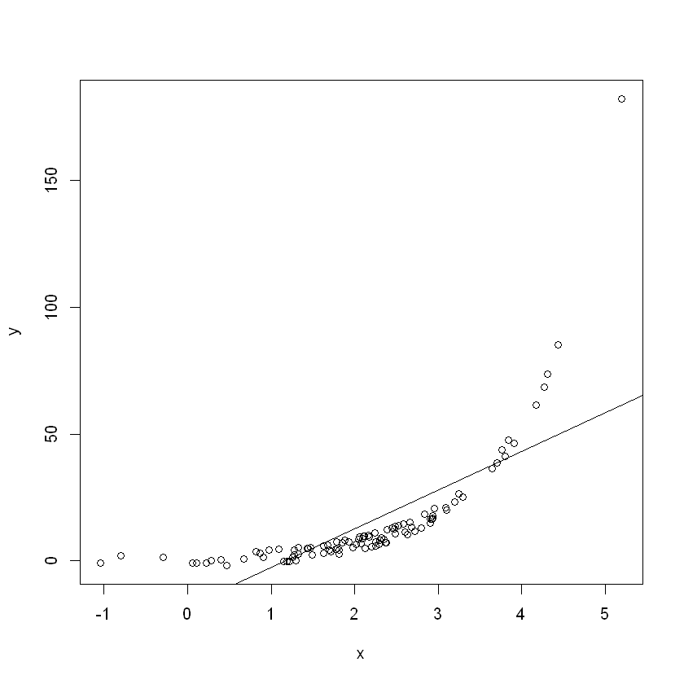

```r
set.seed(2020)

x <- rnorm(100, 2, 1)

y = exp(x) + rnorm(5, 0, 2)

plot(x, y)

#realizamos un modelo de regresion lineal
linear <- lm(y ~ x)

summary(linear)

abline(a = coef(linear[1], b = coef(linear[2], lty = 2)))
```

Datos aleatorizados con un ajuste lineal se acerca al ajuste de algunos puntos de datos, pero no todos (cuanto más se extienda X, más probable es que su ajuste lineal no se aproxime muy bien a los datos).

Primero, dividamos los datos en un conjunto de entrenamiento y prueba usando un muestreo aleatorio simple:

```r
data <- data.frame(x, y)

data.samples <- sample(1:nrow(data), nrow(data) * 0.7, replace = FALSE)

training.data <- data[data.samples, ]
test.data <- data[-data.samples, ]
```

A continuación, aplicamos el modelo lineal en los datos de entrenamiento:

```r
train.linear <- lm(y ~ x, training.data)

summary(train.linear)
```

```
Call:
lm(formula = y ~ x, data = training.data)

Residuals:
   Min     1Q Median     3Q    Max
-6.252 -3.478 -1.319  1.580 33.369

Coefficients:
            Estimate Std. Error t value Pr(>|t|)
(Intercept)  -6.4039     1.5717  -4.075 0.000123 ***
x             8.2830     0.7274  11.388  < 2e-16 ***
---
Signif. codes:  0 '***' 0.001 '**' 0.01 '*' 0.05 '.' 0.1 ' ' 1

Residual standard error: 6.036 on 68 degrees of freedom
Multiple R-squared:  0.656,	Adjusted R-squared:  0.651
F-statistic: 129.7 on 1 and 68 DF,  p-value: < 2.2e-16
```

Ahora que tiene un modelo entrenado, comparemos los valores de salida del modelo con los valores reales. Puede hacer esto utilizando la función **predict()** en R, que toma el objeto **train.linear** y lo aplica a cualquier dato que le proporcione. Debido a los datos de prueba están disponibles, puede usarlos para comparar:

```r
#se va realizar una preadiccion con los datos de test a partir
#de los parámetros obtenidos con el modelo con los datos de entrenamientos.
train.output <- predict(train.linear, test.data)

#obtenemos los valores (y) predicho por el modelo. Luego hay que verificar cuanto difiere estos valores
#con los reales del test data.
train.output
```

**5**

-13.0015878679763

**6**

16.1305907366472

**9**

24.7329578798912

**15**

9.14112204402684

**16**

25.0718297727406

**17**

24.2762711836512

**28**

17.9209166156054

**30**

11.0767930766599

**32**

4.00200599101661

**34**

30.3342684584967

**35**

13.3768681155987

**37**

7.79647711931285

**39**

5.52113638436521

**40**

13.8661437143263

**43**

7.66887161002533

**46**

12.2583016774867

**47**

7.09148667512333

**48**

10.3457988303867

**56**

11.1662020881723

**62**

12.2391044339412

**64**

36.6811782547515

**68**

8.45975384517288

**72**

23.7959381962411

**82**

9.9580044655742

**83**

29.3302007752525

**85**

1.67686556527114

**86**

29.0032544202199

**89**

25.4538737904011

**94**

20.4763721609035

**99**

5.75999483892142

Para la regresión específicamente, puede hacer esto de una de las muchas maneras, dependiendo de los datos y del tipo de análisis de error que desee hacer específicamente. En este caso, utilizará una métrica de prueba llamada **error cuadrático medio o RMSE**:

[figure not shown]

El RMSE toma los valores de salida (y) que el modelo ha proporcionado, resta esos por los (y) valores que tiene en los datos de prueba, luego, divide esos por el número total de observaciones n, suma todos los valores y, finalmente, saca la raíz cuadrada. Así es como se ve el código:

```r
#realizamos una data frame para visualizar los valores predicho, los valores actuales y el error
RMSE.df = data.frame(predicted = train.output, actual = test.data$y,
                        SE = ((train.output - test.data$y)^2/length(train.output)))
RMSE.df
```

|  | predicted | actual | SE |
| --- | --- | --- | --- |
| 5 | -13.001588 | 1.944219 | 7.445905e+00 |
| 6 | 16.130591 | 11.731463 | 6.450776e-01 |
| 9 | 24.732958 | 43.678178 | 1.196405e+01 |
| 15 | 9.141122 | 8.025504 | 4.148682e-02 |
| 16 | 25.071830 | 41.245544 | 8.719634e+00 |
| 17 | 24.276271 | 38.626728 | 6.864521e+00 |
| 28 | 17.920917 | 17.682861 | 1.889017e-03 |
| 30 | 11.076793 | 9.745135 | 5.911043e-02 |
| 32 | 4.002006 | 1.529872 | 2.037149e-01 |
| 34 | 30.334268 | 85.150697 | 1.001614e+02 |
| 35 | 13.376868 | 12.386309 | 3.270691e-02 |
| 37 | 7.796477 | 3.570830 | 5.952031e-01 |
| 39 | 5.521136 | 4.986479 | 9.528611e-03 |
| 40 | 13.866144 | 13.049140 | 2.224982e-02 |
| 43 | 7.668872 | 4.297443 | 3.788843e-01 |
| 46 | 12.258302 | 6.059385 | 1.280886e+00 |
| 47 | 7.091487 | 3.117724 | 5.263598e-01 |
| 48 | 10.345799 | 6.383762 | 5.232579e-01 |
| 56 | 11.166202 | 4.883792 | 1.315622e+00 |
| 62 | 12.239104 | 7.512399 | 7.447247e-01 |
| 64 | 36.681178 | 182.335317 | 7.071709e+02 |
| 68 | 8.459754 | 4.845326 | 4.354696e-01 |
| 72 | 23.795938 | 36.338768 | 5.244086e+00 |
| 82 | 9.958004 | 5.226703 | 7.461739e-01 |
| 83 | 29.330201 | 73.579295 | 6.526608e+01 |
| 85 | 1.676866 | 4.146049 | 2.032289e-01 |
| 86 | 29.003254 | 68.399667 | 5.173591e+01 |
| 89 | 25.453874 | 47.580328 | 1.631933e+01 |
| 94 | 20.476372 | 26.434828 | 1.183440e+00 |
| 99 | 5.759995 | 5.109927 | 1.408626e-02 |

```r
# calculamos el RMSE
sqrt(sum(RMSE.df$SE))
```

31.4619598371522

Considere el valor RMSE resultante de 31.46 como puntaje de error de este modelo. Para ver qué tan bueno es este número, debe compararlo con otro valor RMSE. Puede ejecutar esta misma lógica en un ajuste de función de un grado superior y ver qué tipo de RMSE obtiene como resultado final:

```r
#realizamos un modelo cuadrático
train.quadratic <- lm(y ~ poly(x, 2), training.data)

summary(train.quadratic)

#se va realizar una preadiccion con los datos de test a partir
#de los parámetros obtenidos con el modelo con los datos de entrenamientos.

quadratic.output <- predict(train.quadratic, test.data)

head(quadratic.output)

#realizamos una data frame para visualizar los valores predicho, los valores actuales y error
RMSE.quad.df = data.frame(predicted = quadratic.output, actual = test.data$y,
    SE = ((quadratic.output - test.data$y)^2/length(train.output)))

head(RMSE.quad.df)
```

```
Call:
lm(formula = y ~ poly(x, 2), data = training.data)

Residuals:
    Min      1Q  Median      3Q     Max
-8.8422 -1.9718  0.0703  1.6615 14.0954

Coefficients:
            Estimate Std. Error t value Pr(>|t|)
(Intercept)   9.4970     0.3806   24.95   <2e-16 ***
poly(x, 2)1  68.7323     3.1846   21.58   <2e-16 ***
poly(x, 2)2  42.3987     3.1846   13.31   <2e-16 ***
---
Signif. codes:  0 '***' 0.001 '**' 0.01 '*' 0.05 '.' 0.1 ' ' 1

Residual standard error: 3.185 on 67 degrees of freedom
Multiple R-squared:  0.9056,	Adjusted R-squared:  0.9028
F-statistic: 321.5 on 2 and 67 DF,  p-value: < 2.2e-16
```

**5**

5.43152271155785

**6**

16.3665821200012

**9**

36.9838545898695

**15**

5.45263047370785

**16**

37.958333423132

**17**

35.6900430886565

|  | predicted | actual | SE |
| --- | --- | --- | --- |
| 5 | 5.431523 | 1.944219 | 0.4053763 |
| 6 | 16.366582 | 11.731463 | 0.7161444 |
| 9 | 36.983855 | 43.678178 | 1.4937990 |
| 15 | 5.452630 | 8.025504 | 0.2206559 |
| 16 | 37.958333 | 41.245544 | 0.3601918 |
| 17 | 35.690043 | 38.626728 | 0.2874706 |

```r
# calculamos el RMSE
sqrt(sum(RMSE.quad.df$SE))
```

20.6133352126781

```r
#realizamos un modelo polinomico de grado 9

train.polyn <- lm(y ~ poly(x, 9), training.data)

polyn.output <- predict(train.polyn, test.data)

RMSE.polyn.df = data.frame(predicted = polyn.output, actual = test.data$y,
    SE = ((polyn.output - test.data$y)^2/length(train.output)))

head(RMSE.polyn.df)
```

|  | predicted | actual | SE |
| --- | --- | --- | --- |
| 5 | 12.088944 | 1.944219 | 3.430515e+00 |
| 6 | 13.933244 | 11.731463 | 1.615948e-01 |
| 9 | 40.558737 | 43.678178 | 3.243638e-01 |
| 15 | 6.284093 | 8.025504 | 1.010837e-01 |
| 16 | 42.025570 | 41.245544 | 2.028138e-02 |
| 17 | 38.642172 | 38.626728 | 7.950605e-06 |

```r
sqrt(sum(RMSE.polyn.df$SE))
```

166.392974896212

Hay que tener cuidado con el grado del polinomio, entre mas alto tiende a sobreajustarse a los datos (**overfitting**).

Cuando aprendemos por primera vez cómo ajustar una línea a una serie de puntos de datos en nuestra educación temprana, no tendemos a aprender las complejidades de las técnicas de muestreo, ni a dividir nuestros datos en conjuntos de entrenamiento y prueba. Cuando comenzamos con el ajuste de regresión, comenzamos con un ajuste de línea recta, como se muestra en la Figura:

[figure not shown]

Para esta imagen simple, tenemos un modelo que está bastante mal adaptado a los datos. Significado: que la línea en el gráfico que representa el modelo de aprendizaje automático (regresión lineal simple) no explica la mayoría de los datos; Es un modelo demasiado simple. Los modelos lineales solo pueden ajustarse o representar bien los datos que está trazando. Si, por ejemplo, su modelo coincide con una serie de puntos de datos que eran una línea recta, sería una representación precisa. En el mejor de los casos, la regresión lineal puede ajustarse exactamente a los datos, pero es difícil para un procedimiento simple como este sobreajustar los datos. Debido a que los modelos lineales son difíciles de sobreajustar a los datos, rara vez vemos el uso de conjuntos de entrenamiento y prueba para evaluarlos.

En la siguiente figura el ajuste en este caso es mejor que el caso lineal. El ajuste del modelo tiende a ajustarse a la forma de la mayoría de los puntos de datos, y el modelo se ha vuelto un poco más complejo. Tenemos una ecuación que describe el modelo, y ahora tiene que preocuparse por más salidas derivadas del modelo. Si tuviera que agregar otro par de puntos de datos a la imagen en aproximadamente la misma forma, el cuadrático parece que en general encajará bastante bien en el futuro previsible.

[figure not shown]

Finalmente, con algún tipo de modelo complejo ajustado como el que se ve en la siguiente, casi todos los puntos de datos se ajustan exactamente por el modelo. La desventaja de esto es el futuro poder explicativo. Si seguimos la misma lógica que antes y agregamos algunos puntos de datos más a la imagen, el modelo que se muestra no les quedará bien y tendrá un mayor error.

[figure not shown]

Cuando realiza una validación de entrenamiento/prueba en datos continuos como en el ejemplo de regresión aquí, puede elegir entre una serie de medidas estadísticas como el RMSE. Para datos continuos como el tipo con el que hemos estado probando hasta ahora, hay algunas pruebas estadísticas diferentes con las que puede comparar las salidas de error de sus resultados:

[figure not shown]

## Conjuntos de entrenamiento y prueba: modelado de clasificación

Evalue el desempeño de un modelo de clasificación comenzando con una "matriz de confusión". En una forma simple, puede tomar la representación como una matriz 2 × 2, en la que las clases predichas de salida del modelo se comparan con las clases reales y el recuento de la salida del modelo en las celdas de la matriz. Esto le informa cuántos verdaderos positivos, verdaderos negativos, falsos positivos y falsos negativos hay como resultado. Al igual que con las estadísticas de regresión, las estadísticas de clasificación tienen muchas herramientas con las que puede evaluar el rendimiento final del modelo. Echemos un vistazo a algunos de ellos:

```r
iris.df <- iris

iris.df$Species <- as.character(iris.df$Species)

iris.df$Species[iris.df$Species != "setosa"] <- "other"

iris.df$Species <- as.factor(iris.df$Species)

head(iris.df)
tail(iris.df)
```

| Sepal.Length | Sepal.Width | Petal.Length | Petal.Width | Species |
| --- | --- | --- | --- | --- |
| 5.1 | 3.5 | 1.4 | 0.2 | setosa |
| 4.9 | 3.0 | 1.4 | 0.2 | setosa |
| 4.7 | 3.2 | 1.3 | 0.2 | setosa |
| 4.6 | 3.1 | 1.5 | 0.2 | setosa |
| 5.0 | 3.6 | 1.4 | 0.2 | setosa |
| 5.4 | 3.9 | 1.7 | 0.4 | setosa |

|  | Sepal.Length | Sepal.Width | Petal.Length | Petal.Width | Species |
| --- | --- | --- | --- | --- | --- |
| 145 | 6.7 | 3.3 | 5.7 | 2.5 | other |
| 146 | 6.7 | 3.0 | 5.2 | 2.3 | other |
| 147 | 6.3 | 2.5 | 5.0 | 1.9 | other |
| 148 | 6.5 | 3.0 | 5.2 | 2.0 | other |
| 149 | 6.2 | 3.4 | 5.4 | 2.3 | other |
| 150 | 5.9 | 3.0 | 5.1 | 1.8 | other |

```r
#particionamos la data en datos de entrenamiento y prueba

iris.samples <- sample(1:nrow(iris.df), nrow(iris.df) * 0.7,
    replace = FALSE)

training.iris <- iris.df[iris.samples, ]

test.iris <- iris.df[-iris.samples, ]
```

```r
#aplicamos un modelo de random forest para predecir el tipo de especie
library(randomForest)

iris.rf <- randomForest(Species ~ ., data = training.iris)

iris.predictions <- predict(iris.rf, test.iris)

table(iris.predictions, test.iris$Species)
```

```
iris.predictions other setosa
          other     28      0
          setosa     0     17
```

En una tabla de verdad de clase binaria, hay dos resultados: o el valor predicho es alguna clase, o no lo es. En este caso, te estás enfocando en si el modelo predijo una clase setosa u other. Hay cuatro valores para la tabla de confusión:

**Verdaderos positivos**: El modelo predijo las clases setosa y las acertó.

**Verdaderos negativos**: El modelo predijo las clases other y las acertó.

**Falsos positivos**: El modelo predijo clases setosa , pero la respuesta correcta fue other.

**Falsos negativos**: El modelo predijo clases other , pero la respuesta correcta fue setosa.

El resultado de esta tabla de verdad no es súper interesante, porque era muy preciso. No hubo clases predichas incorrectamente. Sin embargo, en aras de la ilustración, supongamos que teníamos una salida de matriz de confusión que era ligeramente inexacta:

```r
##
##          other setosa
##   other     26      3
##   setosa     2     15
```

Entonces ahora tenemos 15 verdaderos positivos (TP), 26 verdaderos negativos (TN), 2 falsos positivos (FP) y 3 falsos negativos (FN). Con modelos de clasificación como estos, tenemos una serie de estadísticas entre las que podemos elegir probar nuestra precisión:

[figure not shown]

Muchos de estos valores se utilizan como puntos de referencia para los modelos de clasificación. Con los modelos de regresión, tenía su práctico valor RMSE que podía comparar con otros modelos, entonces, ¿cuál sería el punto de referencia correspondiente para la precisión en este caso? Veamos las opciones disponibles:

**Sensitivity**:

A menudo llamado recall , esto es si ud tiene un umbral inferior establecido para su modelo de clasificación. Ud deberia establecer una barra inferior si no quisiera perderse ninguna planta que pudiera ser de un tipo setosa .

**Specificity**:

Lógicamente es lo mismo que precisión, pero para el caso opuesto cuando predice si una planta no es una variante setosa.

**Precision**:

**Accuracy**:

Número de casos verdaderos dividido por el total de casos verdaderos y falsos.

**F1 score**:

Promedio ponderado de puntajes de precisión y Sensitivity.

## Validación cruzada

Hasta ahora, hemos hablado acerca de cómo solo ejecutar un modelo en el 100% de sus datos podría generar un resultado que no se generaliza bien a los nuevos datos entrantes. Esta fue nuestra motivación para dividir los datos con los que comenzamos en un conjunto de entrenamiento, que generalmente toma alrededor del 70% de los datos y un conjunto de prueba que comprende el resto. Se libera el modelo con los datos de entrenamiento y luego usa el conjunto de pruebas para verificar cuál es la salida del modelo en comparación con las respuestas que tienes disponibles.

Sin embargo, este proceso de entrenamiento y prueba de datos aún es algo limitado. En una capacidad, cuando está probando la salida del modelo contra los datos reservados, solo está viendo cuál es el error para esa agrupación exacta de los datos de prueba. En teoría, los datos de la prueba deberían ser representativos de todo el conjunto de datos en su conjunto, pero en la práctica hay casos en los que eso podría no ser cierto. Debería entrenar el modelo de tal manera que pueda estar seguro de que el error es representativo de todo el conjunto de datos, no solo del segmento específico que obtiene de los datos seleccionados al azar que coloca en el conjunto de prueba.

La validación cruzada es una técnica estadística mediante la cual toma todo su conjunto de datos, lo divide en una serie de pequeños fragmentos de entrenamiento / prueba, evalúa el error para cada fragmento y luego promedia esos errores finales. Este enfoque termina siendo una forma más precisa de evaluar si su enfoque de modelado tiene algún problema que podría estar oculto en varias combinaciones de las partes de entrenamiento y prueba del conjunto de datos.

De hecho, ¡ya hemos realizado una forma de validación cruzada! La simple división 70/30 de entrenamiento / prueba que hizo anteriormente que es un tipo de "validación cruzada". Sin embargo, existen muchas otras técnicas estadísticas de validación cruzada, y con R teniendo su base en el diseño estadístico, puede modelar muchos tipos diferentes de validación cruzada.

### Validación cruzada k-Fold

El método **K-Fold Cross-Validation** es un proceso iterativo. Consiste en dividir los datos de forma aleatoria en k grupos de aproximadamente el mismo tamaño. k-1 grupos se emplean para entrenar el modelo y uno de los grupos se emplea como test, este proceso se repite k veces utilizando un grupo distinto como test en cada iteración. El proceso genera k estimaciones del test error cuyo promedio se emplea como estimación final.

El número de iteraciones necesarias viene determinado por el valor k escogido. Por lo general se recomienda un k entre 5 y 10.

K-fold CV es que consigue una estimación precisa del test error rate gracias a un mejor Balance entre bias y varianza.

[figure not shown]

En R, puede usar la función cut para dividir equitativamente los índices de un conjunto de datos dado para su subconjunto.

```r
set.seed(123)

#Creamos un data set
x <- rnorm(100, 2, 1)
y = exp(x) + rnorm(5, 0, 2)
data <- data.frame(x, y)

#revolvemos los datos
data.shuffled <- data[sample(nrow(data)), ]

#Hacermos 10 particiones con los datos, cada dato es clasificado a que corte pertenece
folds <- cut(seq(1, nrow(data)), breaks = 10, labels = FALSE)

#creamos un vector que va a colocar los errores
errors <- c(0)

#En cada particion se hace un proceso: dividir los datos en train/test y luego aplicar un modelo lineal y
#luego se calcula el error.

for (i in 1:10) {

    #obtenemos los indices que pertenecen a cada fold
    fold.indexes <- which(folds == i, arr.ind = TRUE)

    test.data <- data[fold.indexes, ]
    training.data <- data[-fold.indexes, ]

    train.linear <- lm(y ~ x, training.data)
    train.output <- predict(train.linear, test.data)
    errors <- c(errors, sqrt(sum(((train.output - test.data$y)^2/length(train.output)))))
}

#obtenenemos los errores
errors[2:11]
```

1. 4.69618331113536

2. 6.39200157057555

3. 4.76910110022223

4. 4.25984950092693

5. 9.63450513168963

6. 5.07344167567957

7. 7.54783025596053

8. 7.36670283866421

9. 3.97460944170137

10. 10.5398528579595

```r
mean(errors[2:11])
```

6.42540776845148

En este ejemplo, puede ver las salidas de los valores RMSE para 10 cortes diferentes de los datos. Algunos errores son tan bajos como 3.9, otros tan altos como 10.5. Entonces, al usar la validación cruzada, no solo puede ver que hay un alto grado de variabilidad en el RMSE de estos datos, sino que puede mitigar eso tomando el promedio de esos valores para obtener un número final que sea más representativo del error.

### K-fold Cross-Validation con la función `cv.glm()`

La función `cv.glm()` del paquete **boot** puede emplearse para realizar **K-fold Cross-Validation** de cualquier modelo creado mediante la función glm(), especificando el número de grupos en el argumento k.

El resultado de la validación se almacena dentro del vector **delta** que contiene la estimación de error (**MSE**) con y sin corrección.

```r
library(boot)
```

```r
# Se genera el modelo lineal
modelo <- glm(y ~ x, data = data)

# Se emplea la función cv.glm() para la validación, empleando en este caso k=10
set.seed(1)
errors <- cv.glm(data = data, glmfit = modelo, K = 10)
errors$delta
```

1. 47.9868727134652

2. 47.6367155972045

```r
#RMSE
sqrt(errors$delta)
```

1. 6.92725578519122

2. 6.90193564134037

## K-fold Cross-Validation para elegir el grado del polinomio

Ahora, observermos como se distribuyen los datos:

```r
library(ggplot2)
```

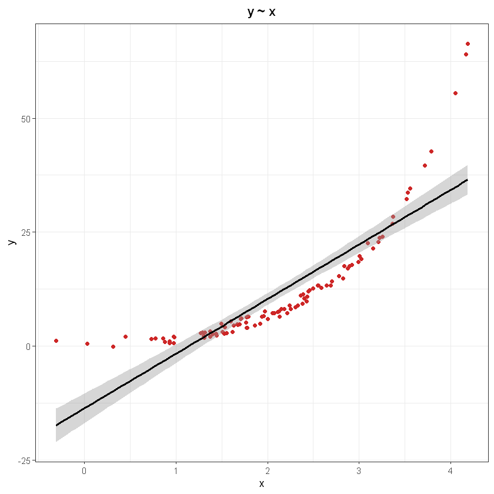

```r
ggplot(data = data, aes(x = x, y = y)) +
geom_point(colour = c("firebrick3")) +
geom_smooth(method = "lm", colour = "black") +
theme_bw() +
labs(title  =  'y ~ x') +
theme(plot.title = element_text(hjust = 0.5, face = 'bold'))
```

Al parecer, un modelo lineal no se ajusta bien los datos. Se puede mejorar el modelo subiendo el grado del polinomio, pero hay que saber hasta q punto hay subirlo. Para conocer cual es el grado de polinomio adecuado, podemos probar diferentes grados y asi ver en cual se obtiene un menor **MSE**. Para esto vamos a emplear la metodologia **K-fold Cross-Validation**

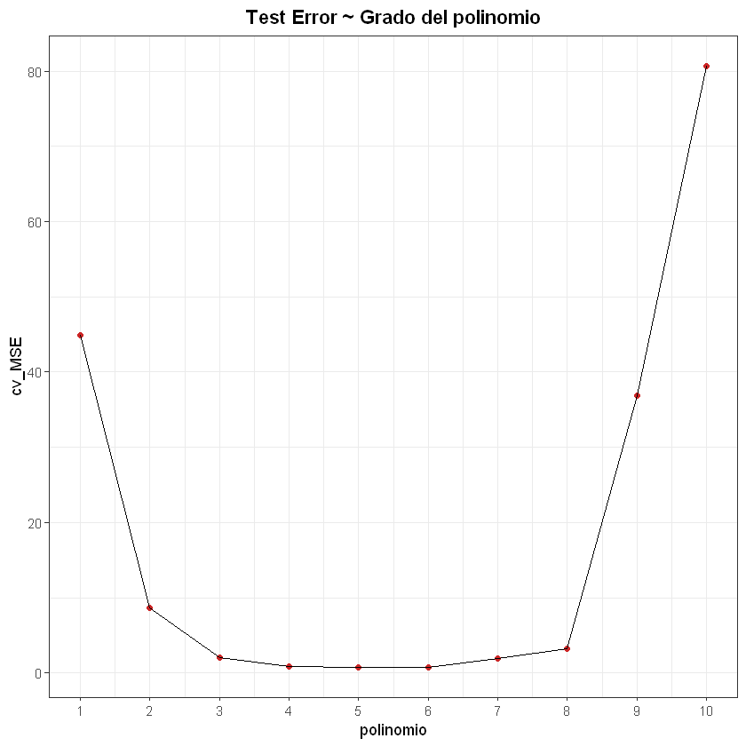

```r
cv_MSE_k10 <- rep(NA,10)

#para cada grado del polinomio se aplica un K-fold Cross-Validation
for (i in 1:10) {
  modelo <- glm(y ~ poly(x, i), data = data)
  set.seed(17)
  cv_MSE_k10[i] <- cv.glm(data = data, glmfit = modelo, K = 10)$delta[1]
}

ggplot(data = data.frame(polinomio = 1:10, cv_MSE = cv_MSE_k10),
       aes(x = polinomio, y = cv_MSE)) +
geom_point(colour = c("firebrick3")) +
geom_path() +
scale_x_continuous(breaks = c(0:10)) +
theme_bw() +
labs(title  =  'Test Error ~ Grado del polinomio') +
theme(plot.title = element_text(hjust = 0.5, face = 'bold'))
```

Bibliografía: Introduction to Machine Learning with R. by Scott V. Burger. March 2018. Publisher: O'Reilly Media, Inc.